# Sequence Analysis of U.S. Returned Students’ Careers (1917)

Cécile Armand

2026-05-03

Abstract

This study employs sequence analysis, implemented through the TraMineR library, to examine the career trajectories of US-educated Chinese based on data from the Who’s Who of American Returned Students (Tsinghua, 1917).

# Introduction

After examining career beginnings of U.S.-returned students, the study employs sequence analysis, implemented through the TraMineR library, to examine their subsequent career trajectories. Sequence analysis is conducted across three dimensions: (1) position level, (2) sector of employment, and (3) place of work to examine **vertical, horizontal, and geographical mobility**. Moreover, sequence analysis combines three temporal dimensions: the calendar year of each position, age at the time of the position, and time elapsed since return.

# Data preparation

```r
# load required packages

library(tidyverse)
library(WeightedCluster)
library(FactoMineR)
library(Factoshiny)
library(forcats)
```

```r
# load position data

career_seq
```

```
## # A tibble: 1,001 × 14
## # Groups:   DocId [263]
##    DocId     name_source start   end  step position level level_code Institution
##    <chr>     <chr>       <dbl> <dbl> <dbl> <chr>    <chr> <chr>      <chr>
##  1 imh-11-2… 張大椿       1911  1911     2 Commiss… Mid-… L3         Industrial…
##  2 imh-11-2… 黃鼎         1911  1911     6 Undeter… Seni… L4         Chinese Ed…
##  3 imh-11-3… 趙國材       1915  1916     5 Acting … Exec… L5         Chinese Ed…
##  4 imh-11-87 余日章       1913  1913     6 Special… Other L0         Convention…
##  5 imh-11-9  王景春       1916  1917     7 Delegate Mid-… L3         Fifth Inte…
##  6 imh-11-1… 陳錦濤       1912  1912    11 Delegate Mid-… L3         Internatio…
##  7 imh-11-3… 歐陽祺       1915  1915     3 Delegate Mid-… L3         Internatio…
##  8 imh-11-1… 徐良         1913  1913     3 Delegate Mid-… L3         Panama Pac…
##  9 imh-11-1… 陳錦濤       1915  1915    12 Commiss… Mid-… L3         Panama Pac…
## 10 imh-11-2… 章祖純       1915  1915     6 Delegate Mid-… L3         Panama Pac…
## # ℹ 991 more rows
## # ℹ 5 more variables: sector <chr>, sector_code <chr>, city <chr>,
## #   province <chr>, area <chr>
```

The resulting dataset includes a total of 1,001 positions across 263 individuals for whom more than one position is reported, representing 65.6% of the initial population (N = 401).

```r
# load attribute data

main_data_all <- read_delim("main_data.csv", delim = ";", escape_double = FALSE, trim_ws = TRUE)
main_data_filtered <- main_data_all %>% filter(DocId %in% career_seq$DocId)
```

```r
main_data_filtered
```

```
## # A tibble: 263 × 38
##    DocId  page name_source FullName_zh FullName_py FullName_wg gender birth_year
##    <chr> <dbl> <chr>       <chr>       <chr>       <chr>       <chr>       <dbl>
##  1 imh-…    19 施肇基      施肇基      Shi Zhaoji  Sze Sao-Ke… Male         1876
##  2 imh-…    24 徐良        徐良        Xu Liang    Chui Leong  Male         1892
##  3 imh-…    28 徐崇欽      徐崇欽      Xu Chongqin Zee C. J    Male         1878
##  4 imh-…    82 章元善      章元善      Zhang Yuan… Djang Yuan… Male         1892
##  5 imh-…    89 黃榮良      黃榮良      Huang Rong… Hwang Yung… Male         1876
##  6 imh-…    92 史鳳珠      史鳳珠      Shi Fengzhu Sze Vong-T… Female         NA
##  7 imh-…    95 黃鼎        黃鼎        Huang Ding  Wong T. T   Male         1874
##  8 imh-…   103 梅華銓(夫人)…… 梅華銓      Mei Huaquan Mei Hua-Ch… Female         NA
##  9 imh-…   113 費興仁      費興仁      Fei Xinren  Fei H. J.   Male         1886
## 10 imh-…   128 楊豹靈(夫人)…… 楊豹靈      Yang Baoli… Yang Pao-L… Female       1890
## # ℹ 253 more rows
## # ℹ 30 more variables: age_in_1917 <dbl>, Birth_Province_zh <chr>,
## #   Birth_Province_eng_standard <chr>, Birth_location_zh <chr>,
## #   Birth_Location_eng_standard <chr>, ancestry_province <chr>,
## #   ancestry_locality <chr>, married <chr>, married_year <dbl>,
## #   marriage_age <dbl>, sons <dbl>, daugthers <dbl>, total_children <dbl>,
## #   Funding <chr>, arrived_year <dbl>, arrived_month <chr>, …
```

# Sequence Analysis

## Vertical Mobility

### Build sequences

```r
# Define alphabet, labels and color scheme

levels <- seqstatl(career_seq$level_code)

levlabels <- c("Other", "Student", "Junior", "Mid-level",
               "Senior",  "Executive",
               "Top executive")

levcolor <- c("#78c679", "#4575b4", "#91bfdb", "#e0f3f8", "#fee090", "#fc8d59", "#d73027")

# Create sequence object

levseq <- seqdef(career_seq, var = c("DocId", "start", "end", "level_code"),
                 informat = "SPELL", states = levels, labels = levlabels, process = FALSE,
                 cpal = levcolor)

# Set year of birth as starting point and compute age at position (using the "process" argument)


levseq_birth <- seqdef(career_seq, var = c("DocId", "start", "end", "level_code"),
                    informat = "SPELL", states = levels, labels = levlabels,
                    process = TRUE,
                    pdata = main_data_filtered,
                    pvar = c("DocId", "birth_year"),
                    cpal = levcolor)


# Focus on the relevant time frame (16-70 y.o.)

levseq_birth_16 <- levseq_birth[, 16:70]

# Set year of return as starting point

levseq_return <- seqdef(career_seq, var = c("DocId", "start", "end", "level_code"),
                        informat = "SPELL", states = levels, labels = levlabels,
                        process = TRUE,
                        pdata = main_data_filtered,
                        pvar = c("DocId", "estimated_returned_year"),
                        cpal = levcolor)

# Rename columns

colnames(levseq_return) <- gsub("^a", "r", colnames(levseq_return))

# Focus on the relevant time frame (1-38 years post-return)

levseq_return_38 <- levseq_return[, 1:38]
```

Note: ‘%’ represent void elements (beginning or end of sequence) whereas * represent gaps or missing data within sequences.

### Visualize sequences

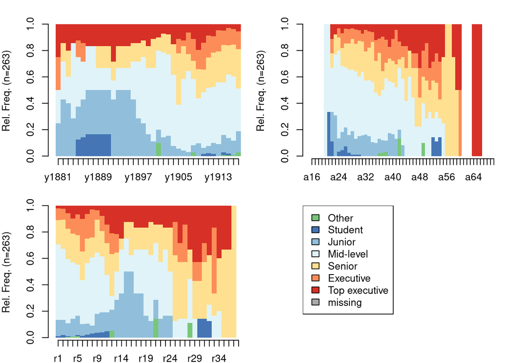

```r
# state distribution plots

par(mar = c(2, 4, 2, 0.5))
par(mfrow = c(2, 2))
seqdplot(levseq, cex.legend=0.7, with.legend = FALSE, border = NA) # based on calendar year
seqdplot(levseq_birth_16, cex.legend=0.7, with.legend = FALSE, border = NA) # based on age at position
seqdplot(levseq_return_38, cex.legend=0.7, with.legend = FALSE, border = NA) # based on time elapsed since return
seqlegend(levseq, cex = 1) # legend
```

### Statistical analyses

```r
# number of distinct sequences (210)
seqtab(levseq, idx=0) %>% nrow
```

```
## [1] 210
```

```r
# most frequent sequences
print(seqtab(levseq))
```

```
##                Freq Percent
## */34-L3/2        10     3.8
## */34-L3/1         9     3.4
## */33-L3/3         6     2.3
## */35-L3/1         5     1.9
## */33-L3/2         4     1.5
## */31-L3/4         3     1.1
## */31-L3/5         3     1.1
## */32-L3/1-L4/1    3     1.1
## */33-L2/2         3     1.1
## */34-L3/1-L4/1    3     1.1
```

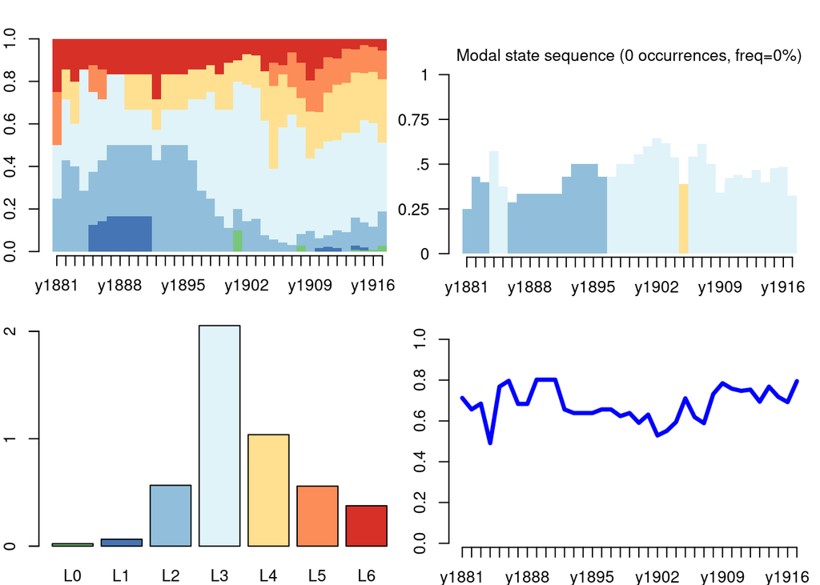

```r
# Entropy, state and mean time distribution

par(mar = c(2, 2, 2, 0.5))
par(mfrow = c(2, 2))
seqdplot(levseq, with.legend = FALSE, border = NA)  # state distribution plot
seqmsplot(levseq, with.legend = FALSE, border = NA) # modal state plot
seqmtplot(levseq, with.legend = FALSE, ylim=c(0, 2)) # mean time plot
seqHtplot(levseq) # transversal entropy plot
```

### Distinct subsequences

```r
# Extract the distinct state-sequence (DSS) for each sequence

level_dss <- seqdss(levseq)
head(level_dss)
```

```
##            Sequence
## imh-11-224 L5-L3
## imh-11-255 L3
## imh-11-318 L3-L5
## imh-11-87  L4-L3-L5-L6
## imh-11-9   L3-L4-L5-L3-L4-L5
## imh-11-193 L3-L4-L3-L6-L3-L4-L6
```

```r
seqtab(level_dss, idx=0) # full list of sub-sequences with their frequencies
```

```
##                                                        Freq Percent
## L3/1                                                     66   25.10
## L3/1-L4/1                                                23    8.75
## L4/1-L3/1                                                18    6.84
## L4/1                                                     17    6.46
## L2/1                                                     13    4.94
## L5/1                                                      9    3.42
## L3/1-L5/1                                                 8    3.04
## L3/1-L2/1                                                 7    2.66
## L5/1-L4/1                                                 6    2.28
## L3/1-L4/1-L3/1                                            5    1.90
## L2/1-L3/1                                                 4    1.52
## L2/1-L4/1                                                 4    1.52
## L2/1-L5/1                                                 4    1.52
## L3/1-L2/1-L3/1                                            3    1.14
## L3/1-L6/1                                                 3    1.14
## L4/1-L5/1                                                 3    1.14
## L5/1-L3/1                                                 3    1.14
## L5/1-L6/1                                                 3    1.14
## L2/1-L4/1-L3/1                                            2    0.76
## L3/1-L4/1-L6/1                                            2    0.76
## L3/1-L5/1-L3/1                                            2    0.76
## L3/1-L6/1-L4/1                                            2    0.76
## L3/1-L6/1-L5/1                                            2    0.76
## L4/1-L3/1-L4/1                                            2    0.76
## L5/1-L3/1-L4/1                                            2    0.76
## L6/1-L3/1                                                 2    0.76
## L1/1                                                      1    0.38
## L1/1-L2/1                                                 1    0.38
## L1/1-L2/1-L3/1                                            1    0.38
## L1/1-L2/1-L4/1                                            1    0.38
## L2/1-L3/1-L2/1                                            1    0.38
## L2/1-L3/1-L4/1-L3/1-L1/1                                  1    0.38
## L2/1-L3/1-L5/1                                            1    0.38
## L2/1-L3/1-L5/1-L3/1-L4/1                                  1    0.38
## L2/1-L4/1-L2/1                                            1    0.38
## L2/1-L5/1-L4/1-L0/1-L5/1-L6/1-L5/1-L0/1-L4/1-L6/1-L5/1    1    0.38
## L3/1-L1/1                                                 1    0.38
## L3/1-L1/1-L5/1                                            1    0.38
## L3/1-L2/1-L3/1-L2/1-L4/1-L5/1                             1    0.38
```

[output cut: 20 more lines]

```
## L4/1-L3/1-L5/1-L4/1-L3/1                                  1    0.38
## L4/1-L3/1-L5/1-L6/1                                       1    0.38
## L4/1-L5/1-L2/1                                            1    0.38
## L4/1-L6/1                                                 1    0.38
## L4/1-L6/1-L3/1-L4/1                                       1    0.38
## L4/1-L6/1-L4/1                                            1    0.38
## L5/1-L2/1                                                 1    0.38
## L5/1-L2/1-L5/1                                            1    0.38
## L5/1-L3/1-L2/1                                            1    0.38
## L5/1-L4/1-L3/1                                            1    0.38
## L5/1-L4/1-L5/1-L3/1                                       1    0.38
## L5/1-L6/1-L3/1                                            1    0.38
## L5/1-L6/1-L4/1-L5/1                                       1    0.38
## L6/1-L3/1-L4/1                                            1    0.38
## L6/1-L3/1-L6/1                                            1    0.38
```

```r
# number of distinct sub-sequences
seqtab(level_dss, idx=0) %>% nrow # 74 unique distinct subsequences
```

```
## [1] 74
```

```r
print(seqtab(level_dss))
```

```
##                Freq Percent
## L3/1             66    25.1
## L3/1-L4/1        23     8.7
## L4/1-L3/1        18     6.8
## L4/1             17     6.5
## L2/1             13     4.9
## L5/1              9     3.4
## L3/1-L5/1         8     3.0
## L3/1-L2/1         7     2.7
## L5/1-L4/1         6     2.3
## L3/1-L4/1-L3/1    5     1.9
```

## Horizontal Mobility

### Build sequences

```r
# Define alphabet, label and color code

sector <- seqstatl(career_seq$sector_code)

sector_label <- c("Central Admin", "Local Admin", "Banking", "Education", "Engineering",
                  "Central Govt", "Local Govt", "Other", "Private", "Railway")

sector_color <- c("#feb24c", "#b2df8a","#6a3d9a", "#fff7bc", "#1f78b4", "#e31a1c", "#31a354", "#b15928", "#cab2d6", "#a6cee3")


# Create sequences

sectseq <- seqdef(career_seq, var = c("DocId", "start", "end", "sector_code"),
                  informat = "SPELL", process = FALSE,
                  states = sector, labels = sector_label,
                  cpal = sector_color)

# set year of birth as starting point and compute age at position (using the "process" argument)

sectseq_birth <- seqdef(career_seq, var = c("DocId", "start", "end", "sector_code"),
                        informat = "SPELL",
                        process = TRUE,
                        states = sector, labels = sector_label,
                        cpal = sector_color,
                        pdata = main_data_filtered,
                        pvar = c("DocId", "birth_year"))

# focus on the relevant time frame (16-70 y.o.)

sectseq_birth_16 <- sectseq_birth[, 16:70]

# set year of return as starting point  (using the "process" argument)

sectseq_return <- seqdef(career_seq, var = c("DocId", "start", "end", "sector_code"),
                        informat = "SPELL",
                        process = TRUE,
                        states = sector, labels = sector_label,
                        cpal = sector_color,
                        pdata = main_data_filtered,
                        pvar = c("DocId", "estimated_returned_year"))


# rename columns

colnames(sectseq_return) <- gsub("^a", "r", colnames(sectseq_return))

# focus on the relevant time frame (from 1 to 38 year after return)

sectseq_return_38 <- sectseq_return[, 1:38]
```

## Visualize sequences

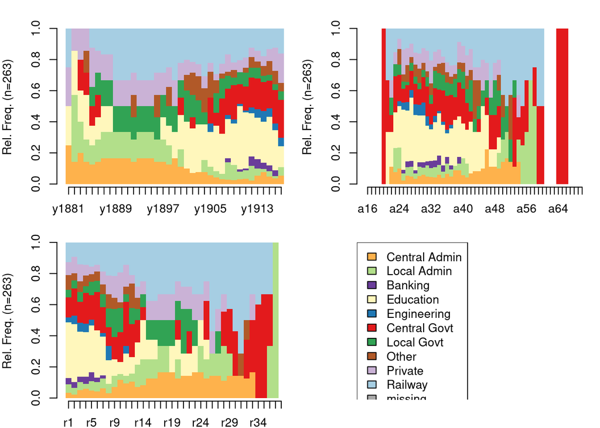

```r
par(mar = c(2, 4, 2, 0.5))
par(mfrow = c(2, 2))
seqdplot(sectseq, cex.legend=0.7, with.legend = FALSE, border = NA)
seqdplot(sectseq_birth_16, cex.legend=0.7, with.legend = FALSE, border = NA)
seqdplot(sectseq_return_38, cex.legend=0.7, with.legend = FALSE, border = NA)
seqlegend(sectseq, ncol = 1, cex = 1)
```

### Statistical Analysis

```r
# number of distinct sequences
seqtab(sectseq, idx=0) %>% nrow # 226 unique sequences (out of 263)
```

```
## [1] 226
```

```r
print(seqtab(sectseq))
```

```
##                   Freq Percent
## */34-EDU/1           6    2.28
## */33-EDU/2           4    1.52
## */34-PRIV/1          4    1.52
## */31-BANK/5          3    1.14
## */34-EDU/1-PRIV/1    3    1.14
## */34-EDU/2           3    1.14
## */35-EDU/1           3    1.14
## */29-RAIL/3          2    0.76
## */30-EDU/2           2    0.76
## */30-EDU/4           2    0.76
```

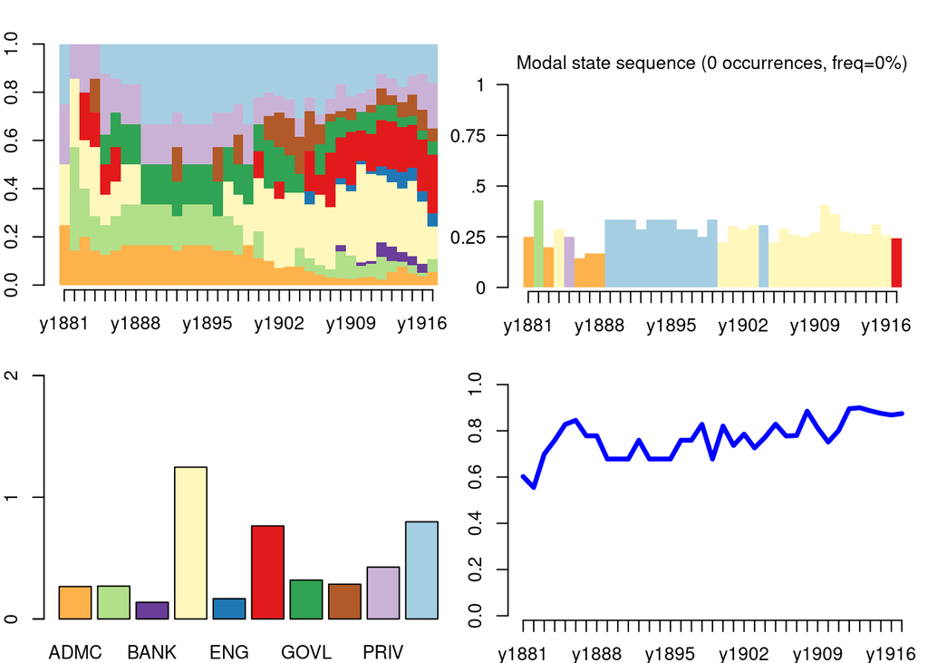

```r
# Entropy, state and mean time distribution

par(mar = c(2, 2, 2, 0.5))
par(mfrow = c(2, 2))
seqdplot(sectseq, with.legend = FALSE, border = NA)
seqmsplot(sectseq, with.legend = FALSE, border = NA)
seqmtplot(sectseq, with.legend = FALSE, ylim=c(0, 2))
seqHtplot(sectseq)
```

```r
# Distinct subsequences

sect_dss <- seqdss(sectseq)
head(sect_dss)
```

```
##            Sequence
## imh-11-224 EDU-ENG
## imh-11-255 EDU-RAIL
## imh-11-318 EDU
## imh-11-87  EDU-GOVC-OTHER
## imh-11-9   GOVC-RAIL-OTHER-GOVC-RAIL
## imh-11-193 GOVC-BANK-GOVC-GOVL-GOVC-OTHER-ADMC-GOVC
```

```r
seqtab(sect_dss, idx=0) # full list of sub-sequences with their frequencies
```

```
##                                                                               Freq
## EDU/1                                                                           43
## RAIL/1                                                                          19
## GOVC/1                                                                          17
## EDU/1-PRIV/1                                                                    10
## PRIV/1                                                                          10
## OTHER/1-EDU/1                                                                    8
## EDU/1-GOVC/1                                                                     7
## EDU/1-OTHER/1                                                                    7
## ENG/1                                                                            4
## OTHER/1                                                                          4
## PRIV/1-EDU/1                                                                     4
## BANK/1                                                                           3
## EDU/1-ENG/1                                                                      3
## EDU/1-RAIL/1                                                                     3
## GOVC/1-EDU/1                                                                     3
## OTHER/1-PRIV/1                                                                   3
## ADMC/1-EDU/1                                                                     2
## ADML/1                                                                           2
## BANK/1-ADMC/1-GOVC/1                                                             2
## EDU/1-ADMC/1                                                                     2
## EDU/1-ADMC/1-GOVC/1                                                              2
## EDU/1-PRIV/1-EDU/1                                                               2
## GOVC/1-ADMC/1                                                                    2
## GOVC/1-GOVL/1-GOVC/1                                                             2
## GOVC/1-OTHER/1                                                                   2
## GOVC/1-RAIL/1                                                                    2
## GOVL/1-GOVC/1                                                                    2
## GOVL/1-RAIL/1                                                                    2
## OTHER/1-GOVC/1                                                                   2
## RAIL/1-EDU/1                                                                     2
## RAIL/1-EDU/1-RAIL/1                                                              2
## RAIL/1-PRIV/1                                                                    2
## ADMC/1-EDU/1-RAIL/1                                                              1
## ADMC/1-GOVC/1                                                                    1
## ADMC/1-GOVC/1-ADML/1                                                             1
## ADMC/1-PRIV/1-ADMC/1                                                             1
## ADMC/1-RAIL/1                                                                    1
## ADML/1-EDU/1                                                                     1
## ADML/1-EDU/1-ADML/1                                                              1
```

[output cut: 177 more lines]

```
## PRIV/1-BANK/1                                                                    0.38
## PRIV/1-GOVC/1                                                                    0.38
## PRIV/1-GOVC/1-EDU/1                                                              0.38
## PRIV/1-GOVL/1-PRIV/1-ENG/1-PRIV/1                                                0.38
## PRIV/1-OTHER/1-EDU/1                                                             0.38
## PRIV/1-RAIL/1                                                                    0.38
## PRIV/1-RAIL/1-GOVC/1-RAIL/1                                                      0.38
## RAIL/1-ADML/1-GOVC/1                                                             0.38
## RAIL/1-BANK/1                                                                    0.38
## RAIL/1-ENG/1                                                                     0.38
## RAIL/1-GOVC/1                                                                    0.38
## RAIL/1-GOVC/1-EDU/1                                                              0.38
## RAIL/1-GOVC/1-RAIL/1                                                             0.38
## RAIL/1-GOVL/1-PRIV/1                                                             0.38
## RAIL/1-GOVL/1-RAIL/1                                                             0.38
```

```r
# number of distinct sub-sequences
seqtab(sect_dss, idx=0) %>% nrow # 115 unique distinct subsequences
```

```
## [1] 115
```

```r
print(seqtab(sect_dss))
```

```
##               Freq Percent
## EDU/1           43    16.3
## RAIL/1          19     7.2
## GOVC/1          17     6.5
## EDU/1-PRIV/1    10     3.8
## PRIV/1          10     3.8
## OTHER/1-EDU/1    8     3.0
## EDU/1-GOVC/1     7     2.7
## EDU/1-OTHER/1    7     2.7
## ENG/1            4     1.5
## OTHER/1          4     1.5
```

## Geographical Mobility

### Build sequences

```r
# Define alphabet, labels, and color scheme

areas <- seqstatl(career_seq$area)
area_label <- c("Overseas", "Beijing-Tianjin", "Guangdong", "Jiangnan", "Other (China)", "Shanghai")
area_color <- c("#91bfdb", "#d53e4f", "#fc8d59", "#fff7bc", "#addd8e", "#c994c7")

# set birth year as starting point

geoseq_birth <- seqdef(career_seq, var = c("DocId", "start", "end", "area"),
                 informat = "SPELL", process = TRUE,
                 states = areas,
                 labels = area_label,
                 cpal = area_color,
                 pdata = main_data_filtered,
                 pvar = c("DocId", "birth_year"))

# focus on the relevant time frame (16-60 y.o.
geoseq_birth_16 <- geoseq_birth[, 16:60]

# set return year as starting point

geoseq_return <- seqdef(career_seq, var = c("DocId", "start", "end", "area"),
                       informat = "SPELL", process = TRUE,
                       states = areas,
                       labels = area_label,
                       cpal = area_color,
                       pdata = main_data_filtered,
                       pvar = c("DocId", "estimated_returned_year"))

# rename columns

colnames(geoseq_return) <- gsub("^a", "r", colnames(geoseq_return))

# focus on the relevant time frame (from 1 to 38 year after return)
geoseq_return_38 <- geoseq_return[, 1:38]
```

### Visualize sequences

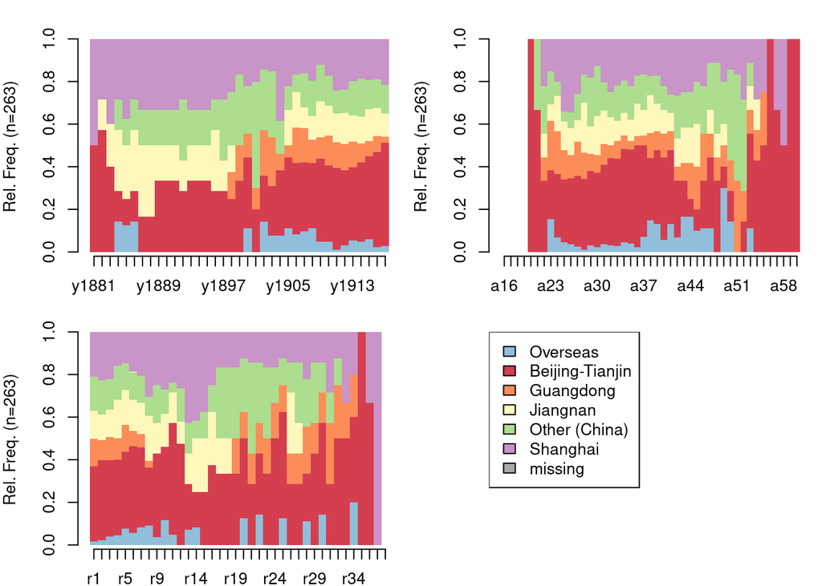

```r
par(mar = c(2, 4, 2, 0.5))
par(mfrow = c(2, 2))
seqdplot(geoseq, cex.legend=0.7, with.legend = FALSE, border = NA)
seqdplot(geoseq_birth_16, cex.legend=0.7, with.legend = FALSE, border = NA)
seqdplot(geoseq_return_38, cex.legend=0.7, with.legend = FALSE, border = NA)
seqlegend(geoseq, cex = 1)
```

### Statistical analysis

```r
# number of distinct sequences

seqtab(geoseq, idx=0) %>% nrow # 212 unique sequences
```

```
## [1] 212
```

```r
print(seqtab(geoseq))
```

```
##                        Freq Percent
## */34-Beijing_Tianjin/2    7     2.7
## */33-Beijing_Tianjin/3    6     2.3
## */34-Beijing_Tianjin/1    5     1.9
## */34-Shanghai/1           5     1.9
## */31-Beijing_Tianjin/5    4     1.5
## */34-Shanghai/2           4     1.5
## */32-Beijing_Tianjin/2    3     1.1
## */33-Beijing_Tianjin/2    3     1.1
## */33-Other_China/2        3     1.1
## */33-Other_China/3        3     1.1
```

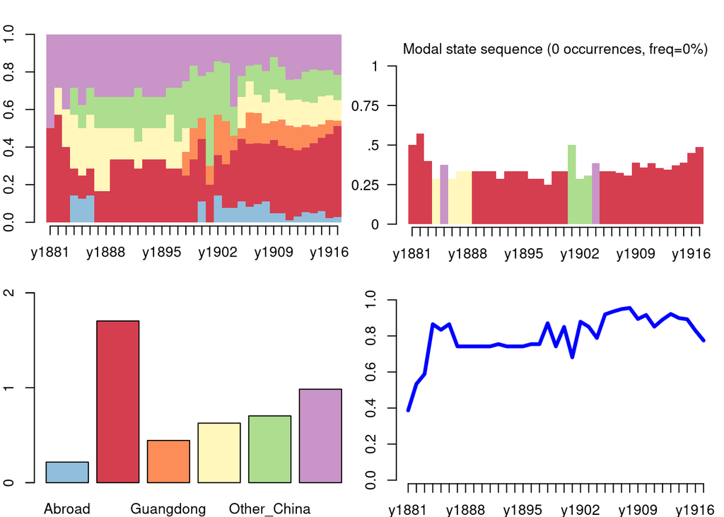

```r
# Entropy, state and mean time distribution

par(mar = c(2, 2, 2, 0.5))
par(mfrow = c(2, 2))
seqdplot(geoseq, with.legend = FALSE, border = NA)
seqmsplot(geoseq, with.legend = FALSE, border = NA)
seqmtplot(geoseq, with.legend = FALSE, ylim=c(0, 2))
seqHtplot(geoseq)
```

### Distinct subsequences

```r
# Distinct subsequences

geo_dss <- seqdss(geoseq)
head(geo_dss)
```

```
##            Sequence
## imh-11-224 Jiangnan
## imh-11-255 Shanghai-Other_China-Shanghai
## imh-11-318 Shanghai-Abroad
## imh-11-87  Other_China-Beijing_Tianjin-Shanghai
## imh-11-9   Beijing_Tianjin-Jiangnan-Beijing_Tianjin-Abroad-Beijing_Tianjin
## imh-11-193 Guangdong-Beijing_Tianjin-Abroad-Beijing_Tianjin
```

```r
seqtab(geo_dss, idx=0) # full list of sub-sequences with their frequencies
```

```
##                                                                                                                                                        Freq
## Beijing_Tianjin/1                                                                                                                                        64
## Shanghai/1                                                                                                                                               30
## Other_China/1                                                                                                                                            16
## Jiangnan/1                                                                                                                                               15
## Guangdong/1                                                                                                                                              13
## Other_China/1-Beijing_Tianjin/1                                                                                                                          10
## Shanghai/1-Other_China/1                                                                                                                                  6
## Beijing_Tianjin/1-Other_China/1                                                                                                                           5
## Jiangnan/1-Shanghai/1                                                                                                                                     5
## Other_China/1-Jiangnan/1                                                                                                                                  5
## Abroad/1                                                                                                                                                  4
## Beijing_Tianjin/1-Jiangnan/1                                                                                                                              4
## Beijing_Tianjin/1-Other_China/1-Beijing_Tianjin/1                                                                                                         4
## Beijing_Tianjin/1-Shanghai/1                                                                                                                              4
## Shanghai/1-Jiangnan/1                                                                                                                                     4
## Guangdong/1-Shanghai/1                                                                                                                                    3
## Jiangnan/1-Beijing_Tianjin/1                                                                                                                              3
## Jiangnan/1-Shanghai/1-Jiangnan/1                                                                                                                          3
## Shanghai/1-Beijing_Tianjin/1                                                                                                                              3
## Abroad/1-Beijing_Tianjin/1                                                                                                                                2
## Beijing_Tianjin/1-Abroad/1                                                                                                                                2
## Beijing_Tianjin/1-Abroad/1-Beijing_Tianjin/1                                                                                                              2
## Beijing_Tianjin/1-Shanghai/1-Beijing_Tianjin/1                                                                                                            2
## Guangdong/1-Beijing_Tianjin/1                                                                                                                             2
## Guangdong/1-Beijing_Tianjin/1-Abroad/1-Beijing_Tianjin/1                                                                                                  2
```

[output cut: 116 more lines]

```r
# number of distinct sub-sequences
seqtab(geo_dss, idx=0) %>% nrow # 70 unique distinct subsequences
```

```
## [1] 70
```

```r
print(seqtab(geo_dss))
```

```
##                                 Freq Percent
## Beijing_Tianjin/1                 64    24.3
## Shanghai/1                        30    11.4
## Other_China/1                     16     6.1
## Jiangnan/1                        15     5.7
## Guangdong/1                       13     4.9
## Other_China/1-Beijing_Tianjin/1   10     3.8
## Shanghai/1-Other_China/1           6     2.3
## Beijing_Tianjin/1-Other_China/1    5     1.9
## Jiangnan/1-Shanghai/1              5     1.9
## Other_China/1-Jiangnan/1           5     1.9
```

# Clustering

## Vertical Mobility

```r
# Detect Longest common subsequence (LCS)

level_lcs <- seqdist(levseq, method = "LCS", with.missing=TRUE, norm = "auto") # normalize
level_lcs_sim <- 1 - seqdist(levseq, method = "LCS", with.missing=TRUE, norm = "auto")

# Clustering using Ward method

level_lcs_ward <- agnes(level_lcs, diss = TRUE, method = "ward")
```

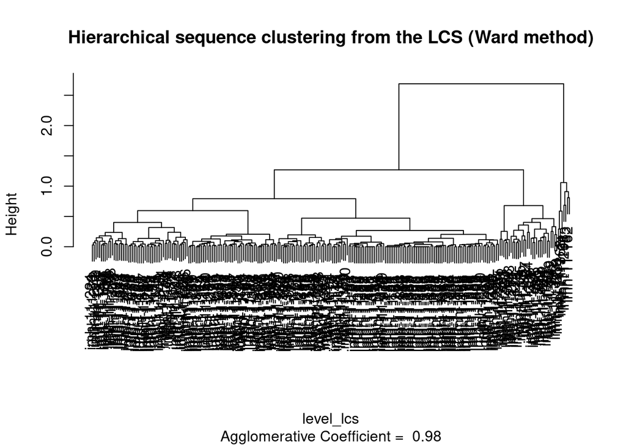

```r
par(mfrow = c(1, 1))
plot(level_lcs_ward, which.plots = 2, main = "Hierarchical sequence clustering from the LCS (Ward method)")
```

```r
# Select 10 clusters

level_lcs_ward10 <- cutree(level_lcs_ward, k = 10)
```

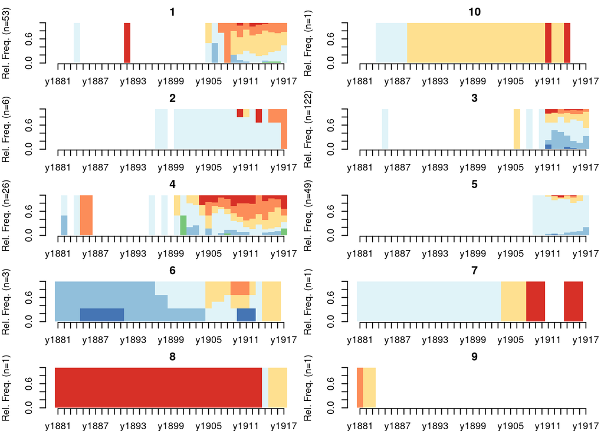

```r
par(mar = c(2, 4, 2, 0.5))
seqdplot(levseq, group=level_lcs_ward10, border=NA, with.legend = FALSE)
```

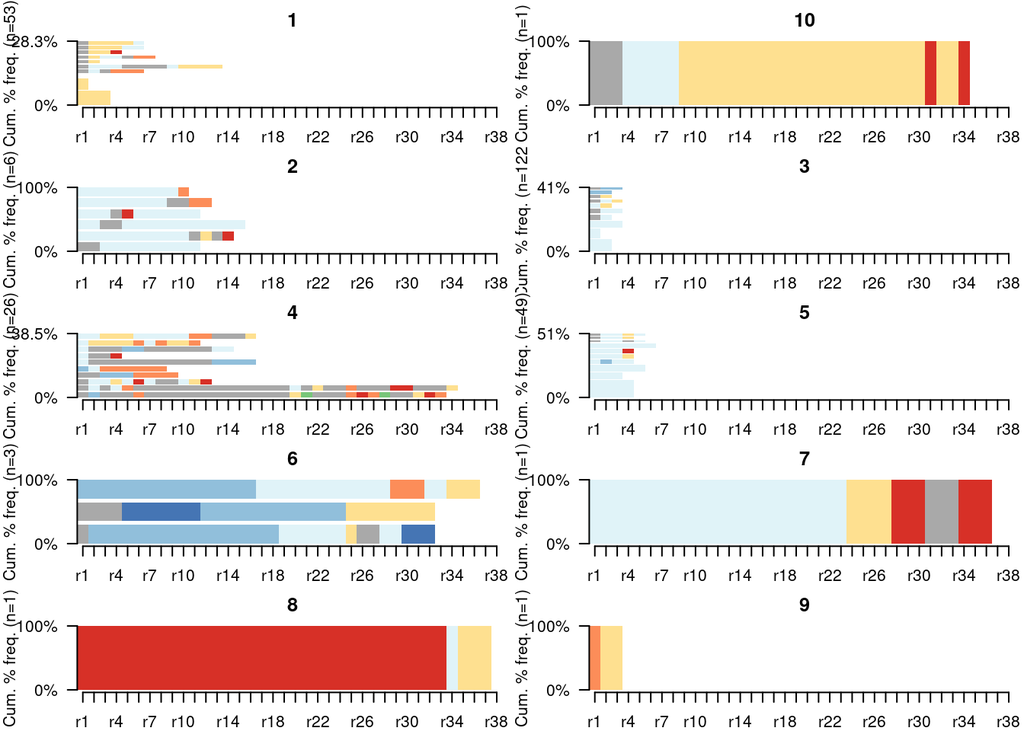

```r
seqfplot(levseq_return_38, group=level_lcs_ward10, border=NA, with.legend = FALSE)
```

```r
# Consolidation with the "partition around medoids" (PAM) method

library(WeightedCluster)

level_lcs_pam10 <- wcKMedoids(level_lcs, k = 10)
```

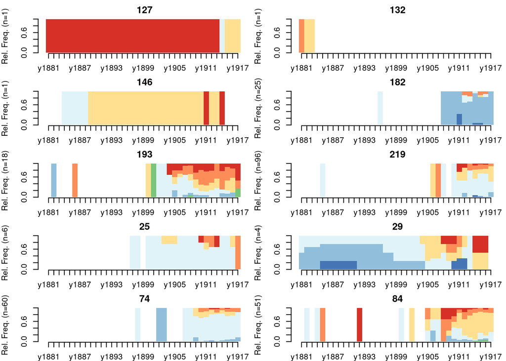

```r
par(mar = c(2, 4, 2, 0.5))
seqdplot(levseq, group=level_lcs_pam10$clustering, border=NA, with.legend = FALSE) # state distribution plot
```

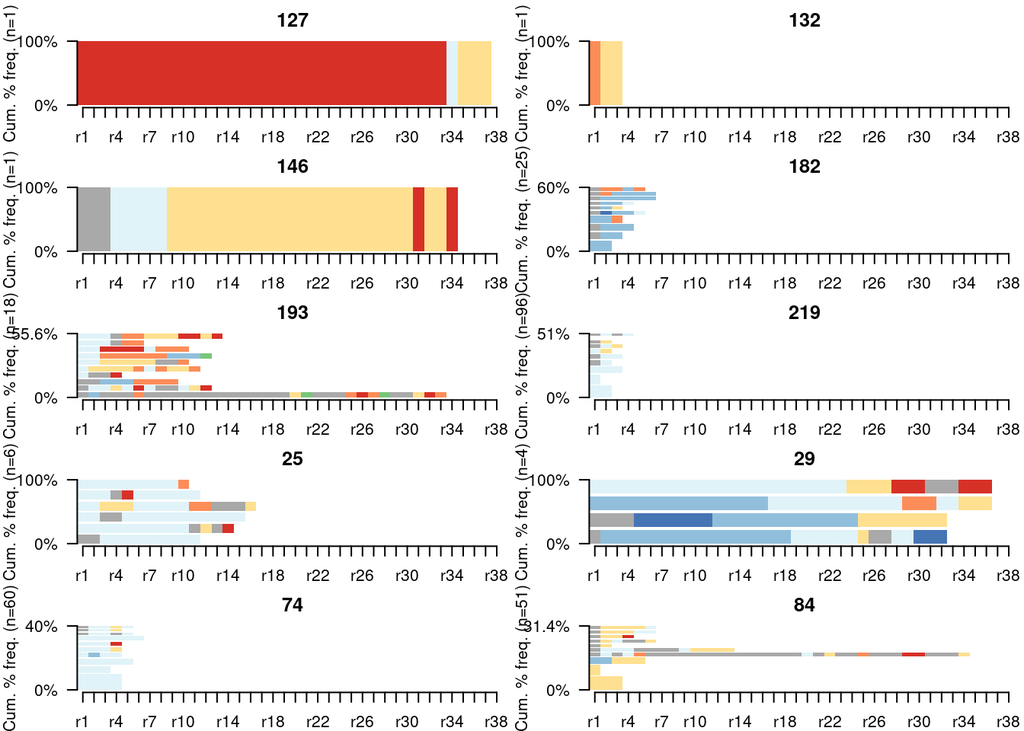

```r
seqfplot(levseq_return_38, group=level_lcs_pam10$clustering, border=NA, with.legend = FALSE) # frequency plot
```

```r
# extract and label clusters
level_cluster <- factor(level_lcs_pam10$clustering)
level_cluster <- as.data.frame(level_cluster)
level_cluster <- rownames_to_column(level_cluster, "level_id")

# retrieve ids

level_ids <- tibble::rownames_to_column(levseq, "DocId")
level_ids <- tibble::rownames_to_column(level_ids, "level_id")
level_ids <- level_ids[1:2]

# join with names
level_ids_name <- left_join(level_ids, names)

level_cluster <- left_join(level_ids, level_cluster)

# label clusters

library(forcats)

level_cluster <- level_cluster %>% mutate(level_cluster_label = fct_collapse(level_cluster,
                                                                                "High" = c("127", "132", "146", "193", "84"),
                                                                                "Low" = c("182", "29"),
                                                                                "Medium" = c("25", "74", "219")))


level_cluster %>% group_by(level_cluster) %>% count(sort = TRUE)
level_cluster %>% group_by(level_cluster_label) %>% count(sort = TRUE)
```

[output not shown]

## Horizontal Mobility

```r
# Clustering based on Longest common subsequence (LCS)

sector_lcs <- seqdist(sectseq, method = "LCS", with.missing=TRUE, norm = "auto") # normalize
sector_lcs_sim <- 1 - seqdist(sectseq, method = "LCS", with.missing=TRUE, norm = "auto")

# Clustering using Ward method

library(cluster)
sector_lcs_ward <- agnes(sector_lcs, diss = TRUE, method = "ward")
```

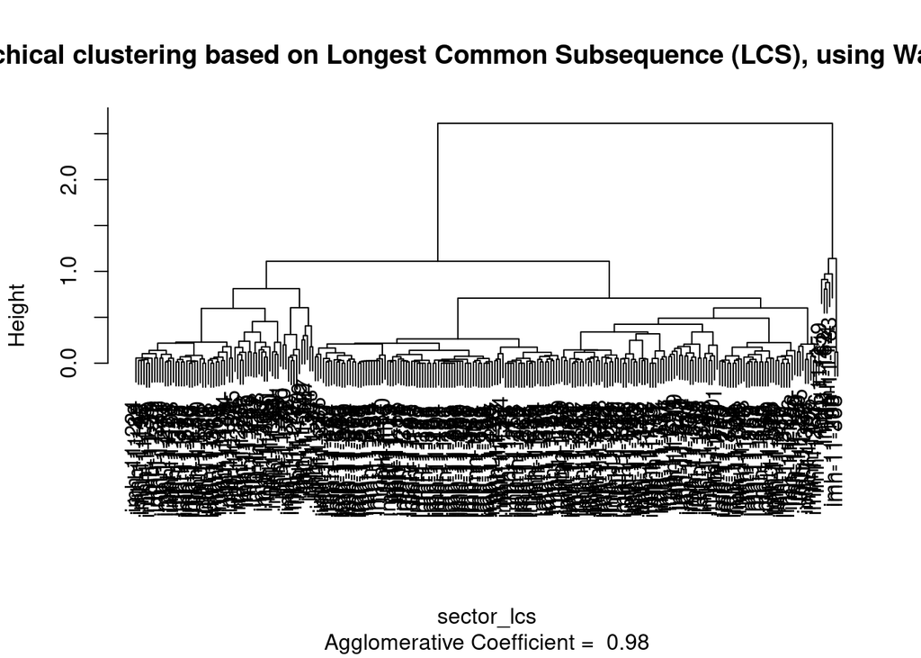

```r
par(mfrow = c(1, 1))
plot(sector_lcs_ward, which.plots = 2, main = "Hierarchical clustering based on Longest Common Subsequence (LCS), using Ward method")
```

```r
# select 10 clusters

sector_lcs_ward10 <- cutree(sector_lcs_ward, k = 10)
```

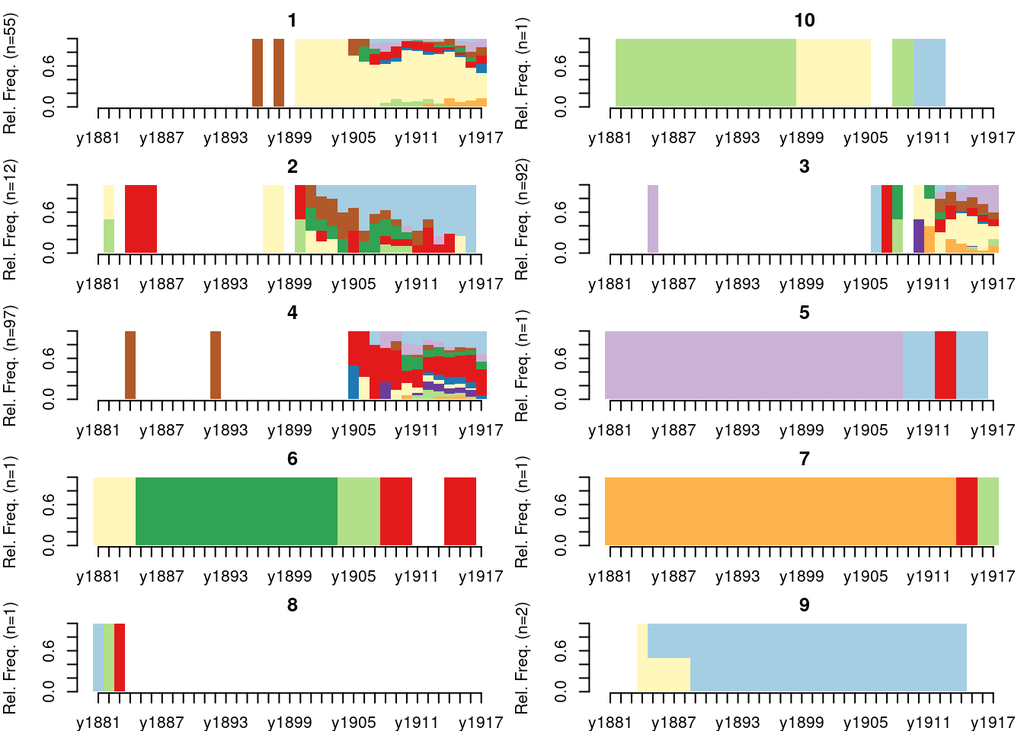

```r
par(mar = c(2, 4, 2, 0.5))
seqdplot(sectseq, group=sector_lcs_ward10, border=NA, with.legend = FALSE)
```

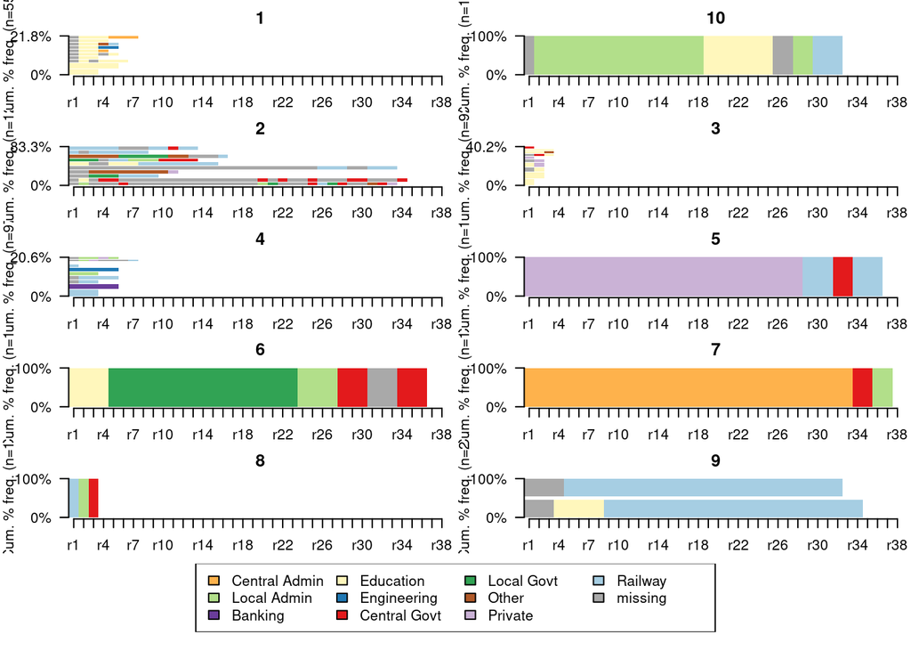

```r
seqfplot(sectseq_return_38, group=sector_lcs_ward10, border=NA)
```

```r
# Consolidation with the "partition around medoids" (PAM) method

library(WeightedCluster)

sector_lcs_pam10 <- wcKMedoids(sector_lcs, k = 10)
```

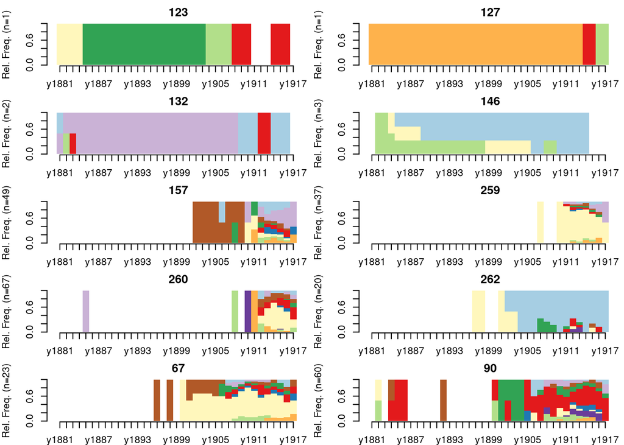

```r
par(mar = c(2, 4, 2, 0.5))
seqdplot(sectseq, group=sector_lcs_pam10$clustering, border=NA, with.legend = FALSE)
```

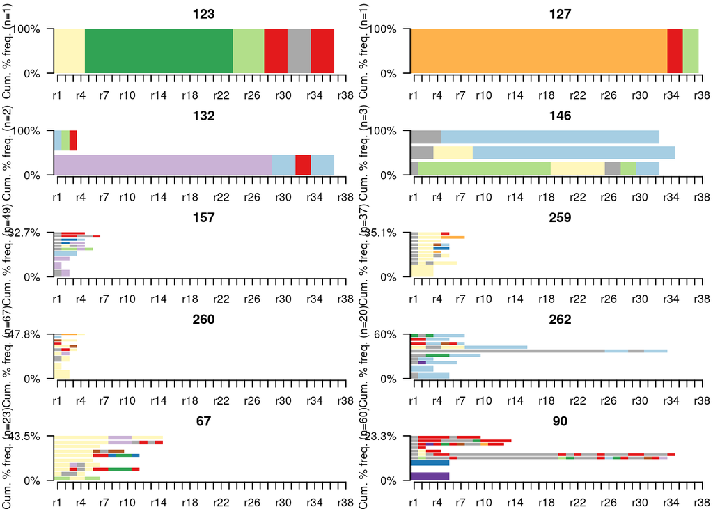

```r
seqfplot(sectseq_return_38, group=sector_lcs_pam10$clustering, border=NA, with.legend = FALSE)
```

```r
# extract and label clusters
library(tidyverse)
sector_cluster <- factor(sector_lcs_pam10$clustering)
sector_cluster <- as.data.frame(sector_cluster)
sector_cluster <- rownames_to_column(sector_cluster, "sector_id")

sector_cluster %>% group_by(sector_cluster) %>% count(sort = TRUE)

# retrieve ids

sector_ids <- tibble::rownames_to_column(sectseq, "DocId")
sector_ids <- tibble::rownames_to_column(sector_ids, "sector_id")
sector_ids <- sector_ids[1:2]

# join with names

sector_id_name <- left_join(sector_ids, names)

sector_cluster <- left_join(sector_ids, sector_cluster)

# label clusters

sector_cluster <- sector_cluster %>% mutate(sector_cluster_label = fct_collapse(sector_cluster,
                                                                        "Railway" = c("146", "262"),
                                                                        "Education" = c("67", "259", "260"),
                                                                        "Official" = c("123", "127", "90"),
                                                                        "Private/Other" = c("132", "157")))

sector_cluster %>% group_by(sector_cluster_label) %>% count(sort = TRUE)
```

## Geographical Mobility

```r
# Detect Longest common subsequence (LCS)

geo_lcs <- seqdist(geoseq, method = "LCS", with.missing=TRUE, norm = "auto") # normalize
geo_lcs_sim <- 1 - seqdist(geoseq, method = "LCS", with.missing=TRUE, norm = "auto")

# Clustering using Ward method

geo_lcs_ward <- agnes(geo_lcs, diss = TRUE, method = "ward")
```

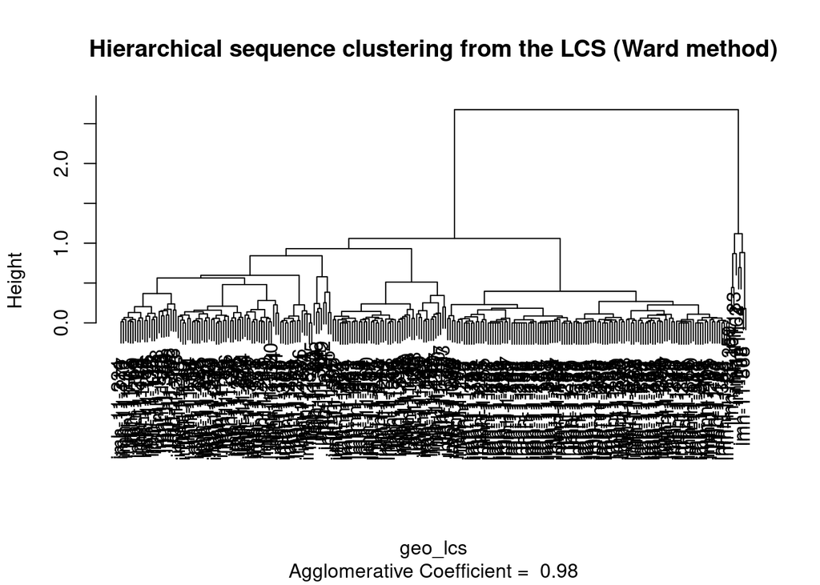

```r
par(mfrow = c(1, 1))
plot(geo_lcs_ward, which.plots = 2, main = "Hierarchical sequence clustering from the LCS (Ward method)")
```

```r
# Consolidation using the PAM method

library(WeightedCluster)

geo_lcs_pam10 <- wcKMedoids(geo_lcs, k=10)
```

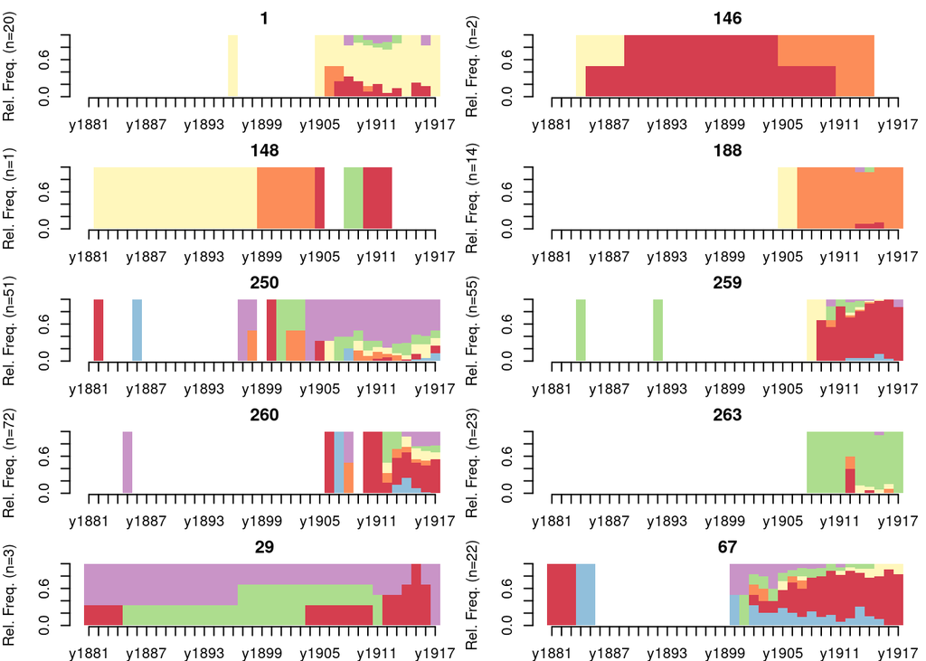

```r
par(mar = c(2, 4, 2, 0.5))
seqdplot(geoseq, group=geo_lcs_pam10$clustering, border=NA, with.legend = FALSE)
```

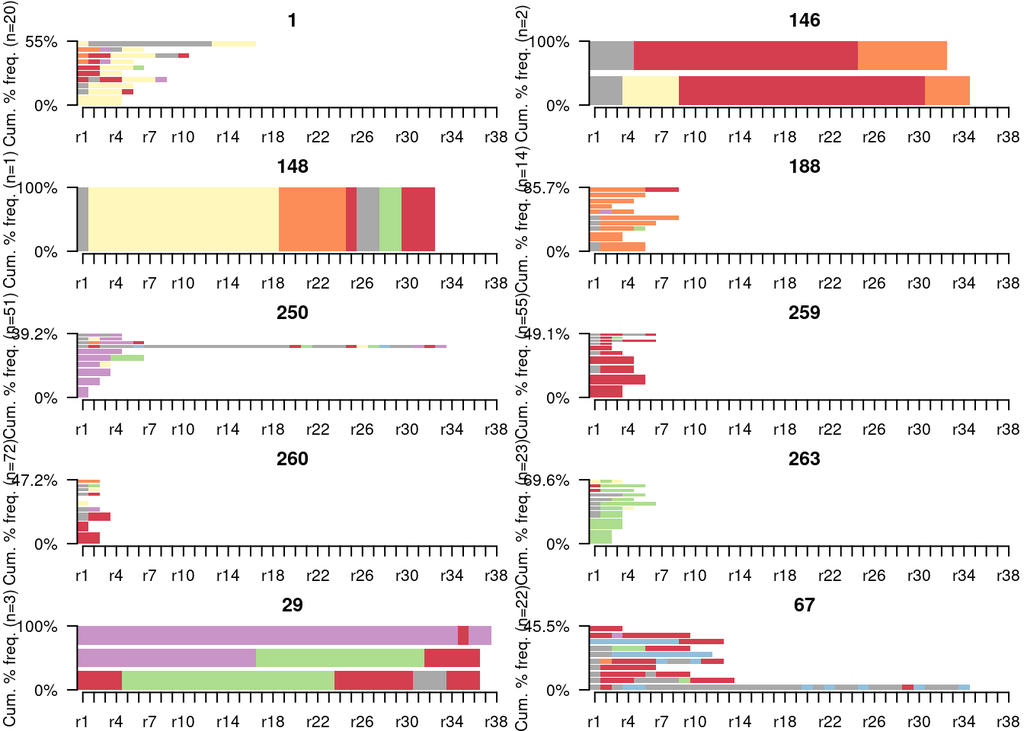

```r
seqfplot(geoseq_return_38, group=geo_lcs_pam10$clustering, border=NA, with.legend = FALSE)
```

```r
# extract and label clusters
geo_cluster <- factor(geo_lcs_pam10$clustering)
geo_cluster <- as.data.frame(geo_cluster)
geo_cluster <- rownames_to_column(geo_cluster, "geo_id")


# retrieve ids

geo_ids <- tibble::rownames_to_column(geoseq, "DocId")
geo_ids <- tibble::rownames_to_column(geo_ids, "geo_id")
geo_ids <- geo_ids[1:2]

# join with names

geo_id_name <- left_join(geo_ids, names)

# join with clusters

geo_cluster <- left_join(geo_ids, geo_cluster)

# label clusters

geo_cluster <- geo_cluster %>% mutate(geo_cluster_label = fct_collapse(geo_cluster,
                                                                             "Metropolitan" = c("146", "259", "67"),
                                                                             "Shanghai" = c("250"),
                                                                             "Jiangnan" = c("1"),
                                                                             "Guangzhou" = c("188"),
                                                                       "Other" = c("263"),
                                                                       "Mobile" = c("29", "148", "260")))

geo_cluster %>% group_by(geo_cluster) %>% count(sort = TRUE)
geo_cluster %>% group_by(geo_cluster_label) %>% count(sort = TRUE)
```

# Multiple Correspondance Analysis

## Data preparation

```r
# join clusters from the three dimensions

sector_cluster$sector_id <- NULL
level_cluster$level_id  <- NULL
geo_cluster$geo_id  <- NULL

sector_cluster$sector_cluster <- NULL
level_cluster$level_cluster  <- NULL
geo_cluster$geo_cluster  <- NULL

clusters_ids <- left_join(sector_cluster, level_cluster)
clusters_ids <- left_join(clusters_ids, geo_cluster)

clusters_ids <- clusters_ids %>% rename(sector = sector_cluster_label, level = level_cluster_label, region = geo_cluster_label)

# join with metadata

meta <- main_data_all %>% select(DocId, Birth_Province_eng_standard, estimated_returned_year, Funding, field2_code)

# regroup/recode variables

meta <- meta  %>%
  mutate(Discipline = fct_collapse(field2_code,
                                "Social Sciences" = c("SOC"),
                                "Humanities" = c("HUM"),
                                "Multiple" = c("MULTI"),
                                "Sciences" = c("NAT", "SCI"),
                                "Other" = c("MIL", "PROF"),
                                "Engineering" = c("ENG")))


meta$Discipline <- replace(meta$Discipline, is.na(meta$Discipline), "Other")



meta <- meta  %>%
  mutate(Nativeplace = fct_collapse(Birth_Province_eng_standard,
                                   "Jiangsu" = c("Jiangsu"),
                                   "Guangdong" = c("Guangdong"),
                                   "Zhejiang" = c("Zhejiang"),
                                   "Hebei-Zhili" = c("Hebei", "Zhili"),
                                   "Other" = c("Fujian", "Hubei", "Jiangxi", "Anhui", "Sichuan", "Shandong", "Henan", "Hunan", "Gansu", "Guangxi"),
                                   "Overseas" = c("Hawaii", "California", "Hongkong", "Malaysia")))

meta$Nativeplace <- replace(meta$Nativeplace, is.na(meta$Nativeplace), "Other")

meta <- meta  %>%
  mutate(Funding = fct_collapse(Funding,
                                "Public" = c("Government support", "Partial support"),
                                "Private" = c("Private support", "Unknown")))


meta$Generation <- cut(meta$estimated_returned_year,
                breaks = c(0, 1911, 1917),  # Define breakpoints
                labels = c("PreBoxer", "PostBoxer"),  # Assign labels
                right = FALSE)


meta$Generation <- replace(meta$Generation, is.na(meta$Generation), "PreBoxer")

names(meta)
```

```
## [1] "DocId"                       "Birth_Province_eng_standard"
## [3] "estimated_returned_year"     "Funding"
## [5] "field2_code"                 "Discipline"
## [7] "Nativeplace"                 "Generation"
```

```r
meta <- meta %>% select(DocId, Generation, Nativeplace, Funding, Discipline)

names(meta)
```

```
## [1] "DocId"       "Generation"  "Nativeplace" "Funding"     "Discipline"
```

```r
summary(meta)
```

```
##     DocId               Generation       Nativeplace     Funding
##  Length:401         PreBoxer :100   Jiangsu    :137   Public :223
##  Class :character   PostBoxer:301   Guangdong  :102   Private:178
##  Mode  :character                   Other      : 71
##                                     Zhejiang   : 39
##                                     Hebei-Zhili: 30
##                                     Overseas   : 20
##                                     (Other)    :  2
##            Discipline
##  Engineering    :112
##  Humanities     : 32
##  Other          : 35
##  Multiple       : 38
##  Sciences       : 47
##  Social Sciences:137
##
```

```r
# join with clusters

cluster_meta <- left_join(meta, clusters_ids)

# prepare data for mca with and without metadata

cluster_mca <- column_to_rownames(clusters_ids, "DocId")
cluster_meta_mca <- column_to_rownames(cluster_meta, "DocId")
```

## Multidimensional Mobility

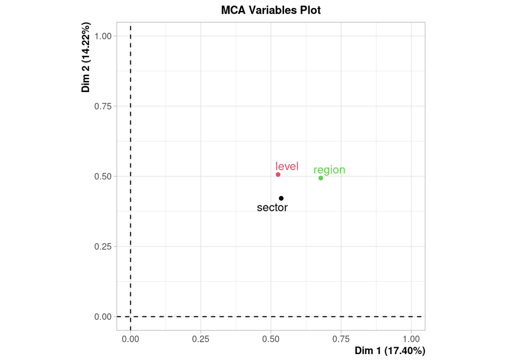

```r
library(FactoMineR)
res.MCA1<-MCA(cluster_mca,graph=FALSE)
plot.MCA(res.MCA1, choix='var',title="MCA Variables Plot",col.var=c(1,2,3))
```

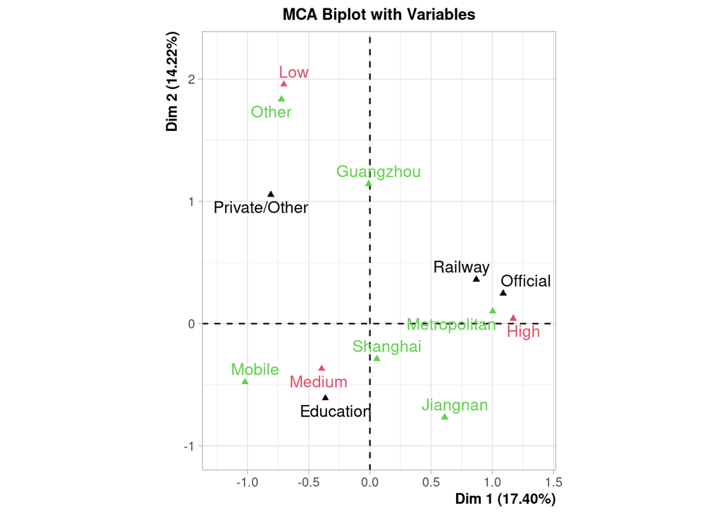

```r
plot.MCA(res.MCA1,invisible= 'ind',col.var=c(1,1,1,1,2,2,2,3,3,3,3,3,3),title="MCA Biplot with Variables",label =c('var'))
```

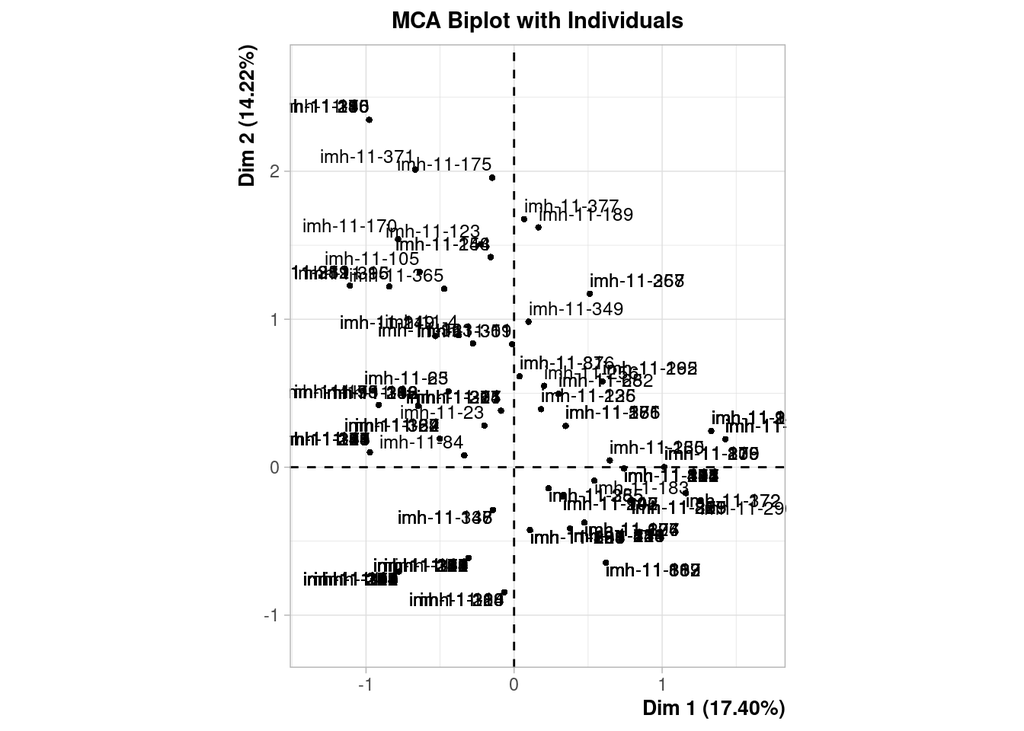

```r
plot.MCA(res.MCA1,invisible= 'var', cex = 0.8, title="MCA Biplot with Individuals",label =c('ind'))
```

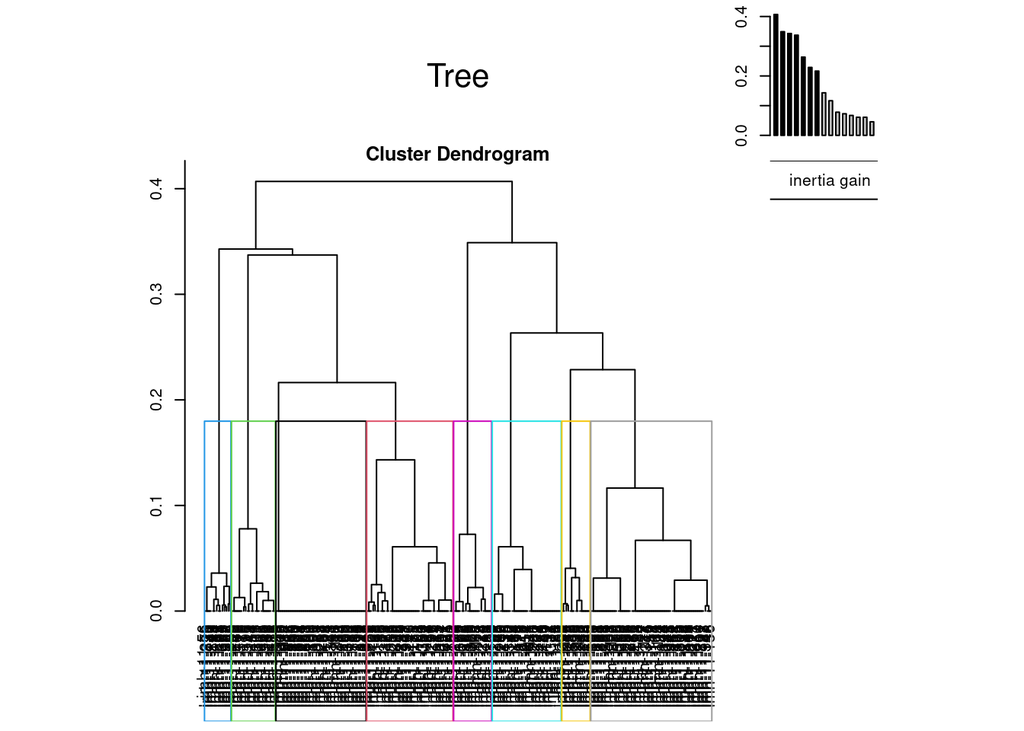

```r
# Hierarchical Clustering (10 dimensions, 8 clusters)

res.MCA1<-MCA(cluster_mca,ncp=10,graph=FALSE)
res.HCPC1<-HCPC(res.MCA1,nb.clust=8,consol=FALSE,graph=FALSE)
plot.HCPC(res.HCPC1,choice='tree',title='Tree')
```

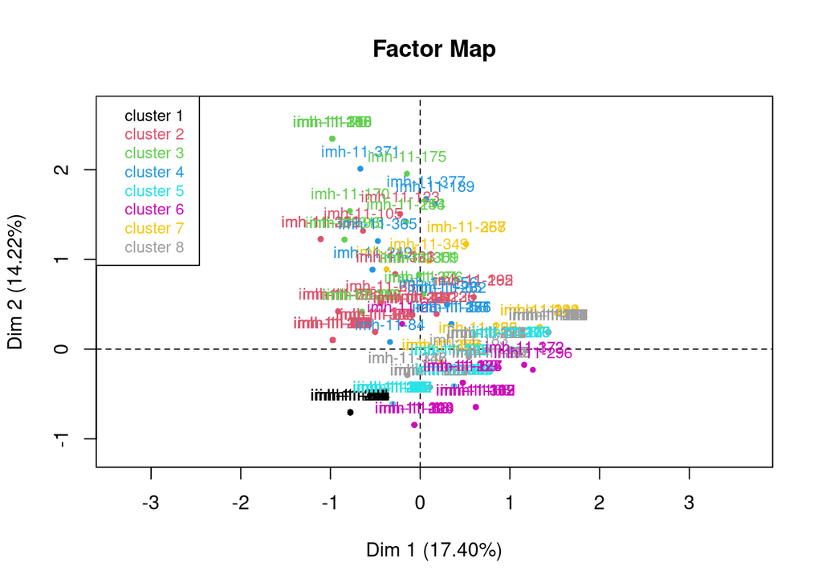

```r
plot.HCPC(res.HCPC1,choice='map',draw.tree=FALSE,title='Factor Map')
```

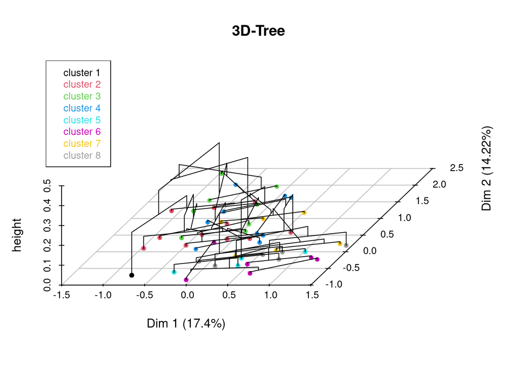

```r
plot.HCPC(res.HCPC1,choice='3D.map',ind.names=FALSE,centers.plot=FALSE,angle=60,title='3D-Tree')
```

```r
summary(res.HCPC1)
```

```
##            Length Class      Mode
## data.clust 4      data.frame list
## desc.var   3      catdes     list
## desc.axes  3      catdes     list
## desc.ind   2      -none-     list
## call       7      -none-     list
```

## Career and attribute data

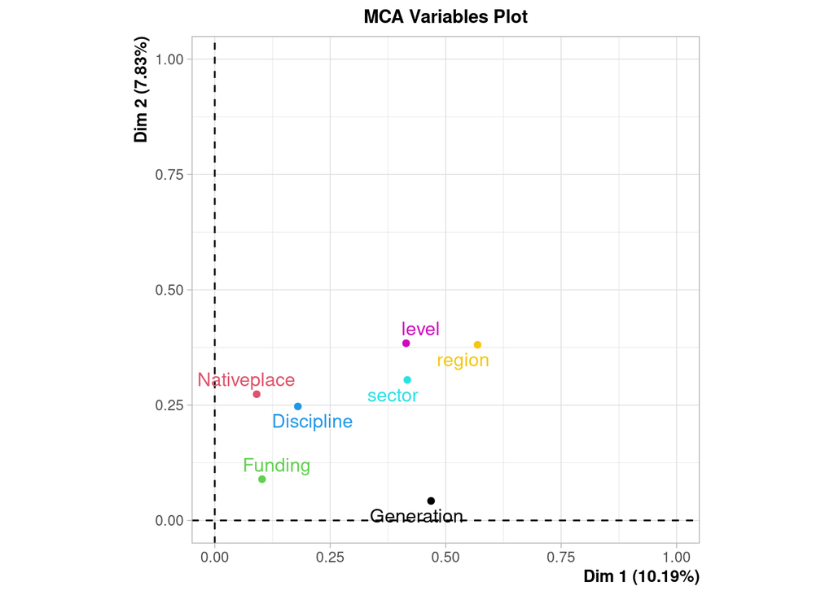

```r
cluster_meta_mca_na <- cluster_meta_mca %>% drop_na(level) %>% drop_na(sector) %>% drop_na(region)

res.MCA2<-MCA(cluster_meta_mca_na,graph=FALSE)
plot.MCA(res.MCA2, choix='var',title="MCA Variables Plot",col.var=c(1,2,3,4,5,6,7))
```

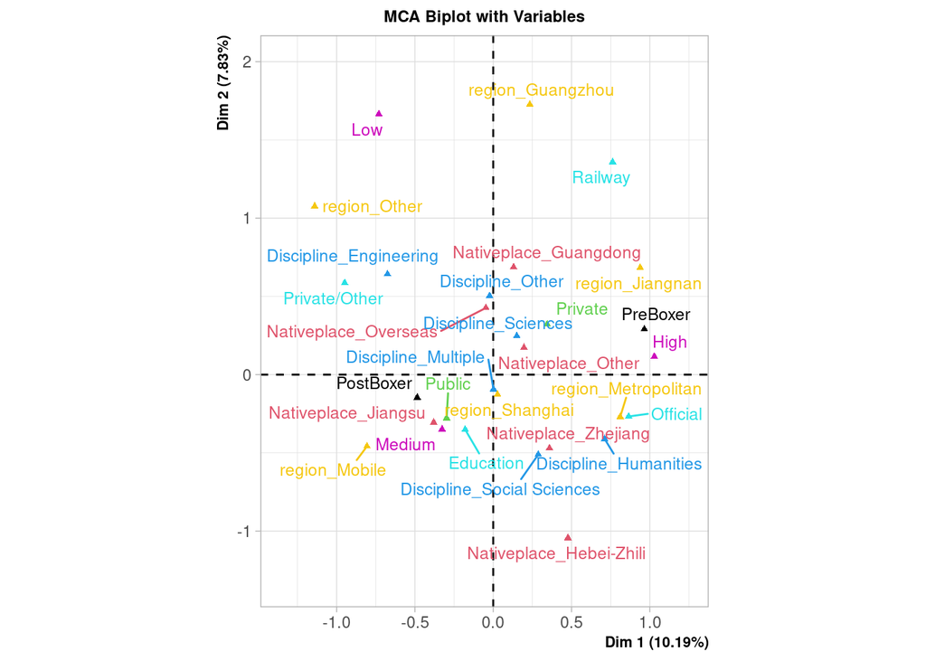

```r
plot.MCA(res.MCA2,invisible= 'ind',col.var=c(1,1,2,2,2,2,2,2,3,3,4,4,4,4,4,4,5,5,5,5,6,6,6,7,7,7,7,7,7),title="MCA Biplot with Variables",cex=0.8,cex.main=0.8,cex.axis=0.8,label =c('var'))
```

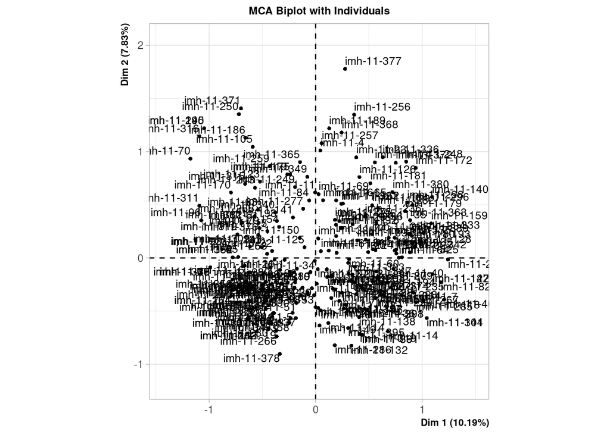

```r
plot.MCA(res.MCA2,invisible= 'var',title="MCA Biplot with Individuals",cex=0.8,cex.main=0.8,cex.axis=0.8,label =c('ind'))
```

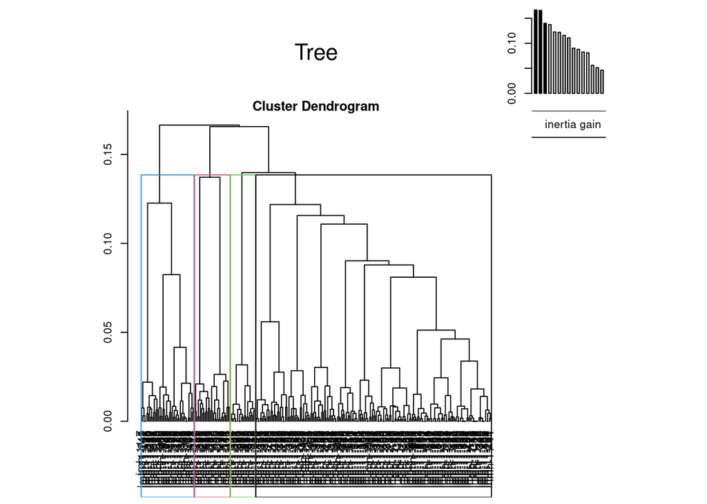

```r
# Hierarchical clustering with 4 clusters

res.MCA2<-MCA(cluster_meta_mca_na,ncp=22,graph=FALSE)
res.HCPC2<-HCPC(res.MCA2,nb.clust=4,consol=FALSE,graph=FALSE)
plot.HCPC(res.HCPC2,choice='tree',title='Tree')
```

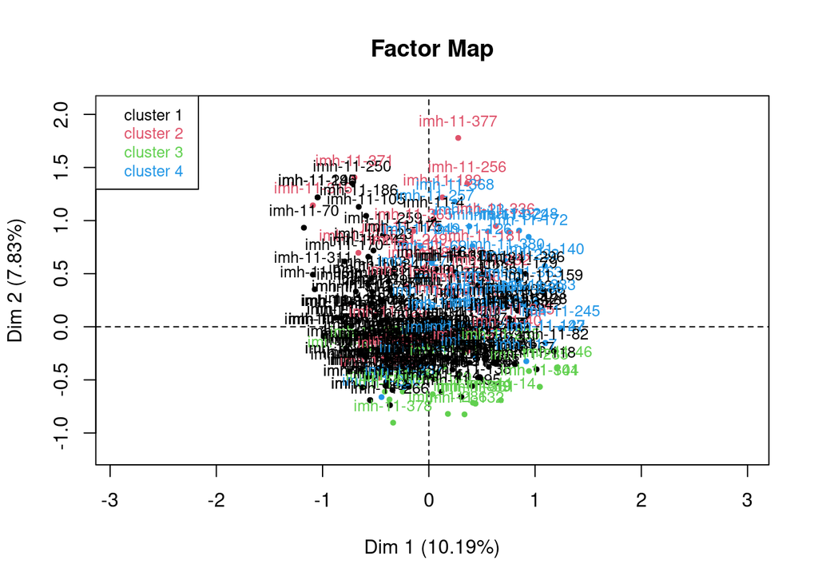

```r
plot.HCPC(res.HCPC2,choice='map',draw.tree=FALSE,title='Factor Map')
```

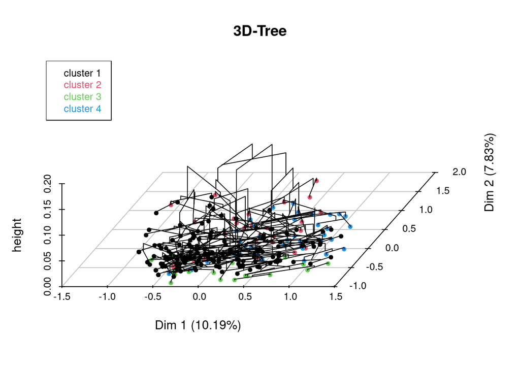

```r
plot.HCPC(res.HCPC2,choice='3D.map',ind.names=FALSE,centers.plot=FALSE,angle=60,title='3D-Tree')
```